# SeqNet: An R Package for Generating Gene-Gene Networks and Simulating RNA-Seq Data

Authors

Tyler Grimes

Somnath Datta

Published

July 10, 2021

In [*Journal of Statistical Software*](https://www.jstatsoft.org/article/view/v098i12)

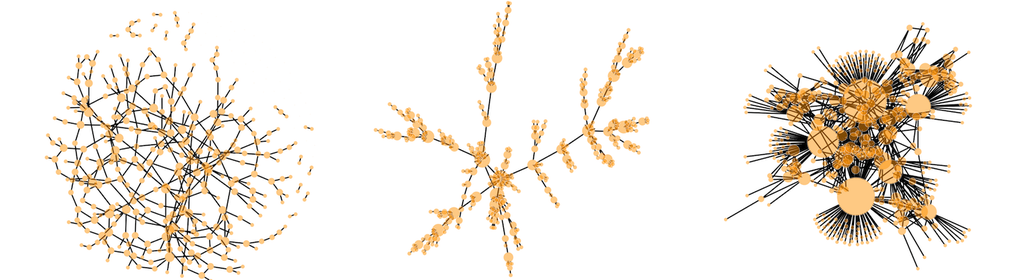

## Abstract

Gene expression data provide an abundant resource for inferring connections in gene regulatory networks. While methodologies developed for this task have shown success, a challenge remains in comparing the performance among methods. Gold-standard datasets are scarce and limited in use. And while tools for simulating expression data are available, they are not designed to resemble the data obtained from RNA-seq experiments. SeqNet is an R package that provides tools for generating a rich variety of gene network structures and simulating RNA-seq data from them. This produces in silico RNA-seq data for benchmarking and assessing gene network inference methods. The package is available on CRAN and on GitHub at https://github.com/tgrimes/SeqNet.

## Summary

`SeqNet` is an R package that provides tools for generating a rich variety of gene network structures and simulating RNA-seq data from them. This produces in silico RNA-seq data for benchmarking and assessing gene network inference methods.

doi: 10.18637/jss.v098.i12

`SeqNet` R package [available on CRAN](https://cran.r-project.org/web/packages/SeqNet/index.html)